# Portfoliomanagement and Financial Analysis - Assignment 4

Submit until Monday 2019-10-07, 13:00

Lukas Salcher

```r
pacman::p_load(tidyverse,tidyquant,PortfolioAnalytics,nloptr,timetk, MASS,timeSeries, fEcofin, fPortfolio)
```

**Please** remember to put your assignment solutions in `rmd` format using **many** chunks and putting readable text in between, similar to my examples given in Research Methods and Assignment 1! Also, each student has to select his own set of 10 stocks having data available as of `2000-01-01`. Select by Sharpe-ratio, dominance or any other method (e.g. matching your first name).

For all exercises: Please use the Assignment-Forum to post your questions, I will try my best to help you along!

## Exercise 1: Rebalancing

Have a look at `vignette("ROI_vignette")` and the `optimize.portfolio.rebalancing` command. Use your dataset to compute

1. Mean-Return (tangency portfolio)

```r
stocks <- colnames(xts.returns.wide)
init <- portfolio.spec(assets=stocks)
init <- add.constraint(portfolio=init, type="box", min=0.05, max=0.4)

meanvar.portf <- add.objective(portfolio=init, type="risk", name="var", risk_aversion=10)
meanvar.portf <- add.objective(portfolio=meanvar.portf, type="return", name="mean")
meanvar.opt <- optimize.portfolio(R=xts.returns.wide, portfolio=meanvar.portf, optimize_method="ROI", trace=TRUE)
print(meanvar.opt)
```

```
PortfolioAnalytics Optimization

Call:
optimize.portfolio(R = xts.returns.wide, portfolio = meanvar.portf,
    optimize_method = "ROI", trace = TRUE)

Optimal Weights:
 AAPL  MSFT  AMZN  NVDA  ADBE  CSCO  AMGN  QCOM   UPS  ORCL
0.050 0.050 0.050 0.050 0.050 0.050 0.229 0.050 0.371 0.050

Objective Measure:
   mean
0.01078


 StdDev
0.05098
```

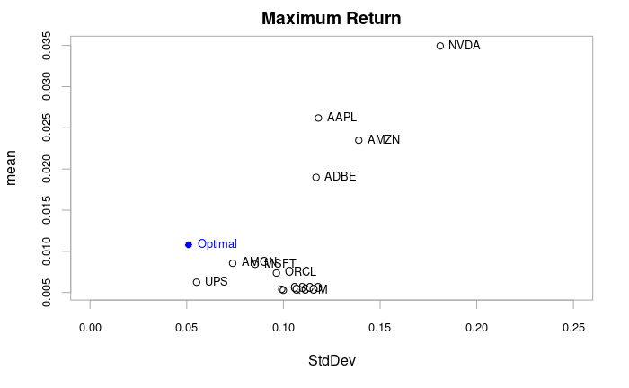

```r
chart.RiskReward(meanvar.opt, return.col="mean", risk.col="StdDev", chart.assets=TRUE, xlim=c(0.00,0.25), main="Maximum Return")
```

```r
meanvar.bt <- optimize.portfolio.rebalancing(R=xts.returns.wide, portfolio=meanvar.portf, optimize_method = "ROI", rebalance_on="months", training_period=24, rolling_window=48)
```

```
executing %dopar% sequentially: no parallel backend registered
```

```r
print(meanvar.bt)
```

```
PortfolioAnalytics Optimization with Rebalancing

Call:
optimize.portfolio.rebalancing(R = xts.returns.wide, portfolio = meanvar.portf,
    optimize_method = "ROI", rebalance_on = "months", training_period = 24,
    rolling_window = 48)

Number of rebalancing dates:  201
First rebalance date:
[1] "2001-12-31"
Last rebalance date:
[1] "2018-08-30"

Annualized Portfolio Rebalancing Return:
[1] 0.1847849

Annualized Portfolio Standard Deviation:
[1] 0.1786043
```

2. Minimum-Variance

```r
minvar.port <- add.objective(init, type="risk", name="var")
minvar.opt <- optimize.portfolio(xts.returns.wide, minvar.port, optimize_method="ROI", trace=TRUE)
print(minvar.opt)
```

```
PortfolioAnalytics Optimization

Call:
optimize.portfolio(R = xts.returns.wide, portfolio = minvar.port,
    optimize_method = "ROI", trace = TRUE)

Optimal Weights:
 AAPL  MSFT  AMZN  NVDA  ADBE  CSCO  AMGN  QCOM   UPS  ORCL
0.050 0.050 0.050 0.050 0.050 0.050 0.214 0.050 0.386 0.050

Objective Measure:
 StdDev
0.05096
```

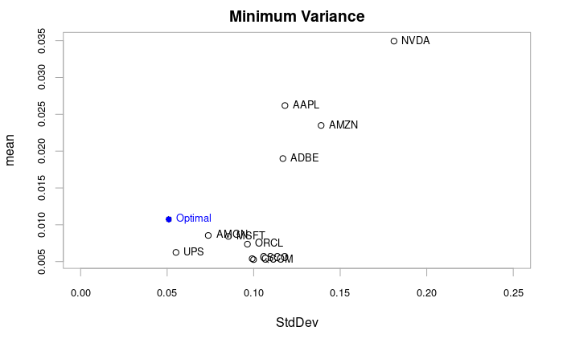

```r
chart.RiskReward(minvar.opt, return.col="mean", risk.col="StdDev", chart.assets=TRUE, xlim=c(0.00,0.25), main="Minimum Variance")
```

```r
minvar.bt <- optimize.portfolio.rebalancing(xts.returns.wide, minvar.port, optimize_method = "ROI", rebalance_on="months", training_period=24, rolling_window=48); print(minvar.bt)
```

```
PortfolioAnalytics Optimization with Rebalancing

Call:
optimize.portfolio.rebalancing(R = xts.returns.wide, portfolio = minvar.port,
    optimize_method = "ROI", rebalance_on = "months", training_period = 24,
    rolling_window = 48)

Number of rebalancing dates:  201
First rebalance date:
[1] "2001-12-31"
Last rebalance date:
[1] "2018-08-30"

Annualized Portfolio Rebalancing Return:
[1] 0.1565901

Annualized Portfolio Standard Deviation:
[1] 0.1657028
```

3. Maximum Quadratic Utility Portfolios

```r
box.const <- box_constraint(type="long_only", assets=init$assets)
ret.obj <- return_objective(name="mean")
var.obj <- portfolio_risk_objective(name="var", risk_aversion=0.25)
qu.const <- list(box.const)
qu.obj <- list(ret.obj,var.obj)

qu.opt <- optimize.portfolio(R=xts.returns.wide, portfolio=init, constraints = qu.const, objectives=qu.obj, optimize_method = "ROI", trace=TRUE)
print(qu.opt)
```

```
PortfolioAnalytics Optimization

Call:
optimize.portfolio(R = xts.returns.wide, portfolio = init, constraints = qu.const,
    objectives = qu.obj, optimize_method = "ROI", trace = TRUE)

Optimal Weights:
  AAPL   MSFT   AMZN   NVDA   ADBE   CSCO   AMGN   QCOM    UPS   ORCL
0.2019 0.0000 0.0000 0.7981 0.0000 0.0000 0.0000 0.0000 0.0000 0.0000

Objective Measure:
   mean
0.03317


StdDev
0.1569
```

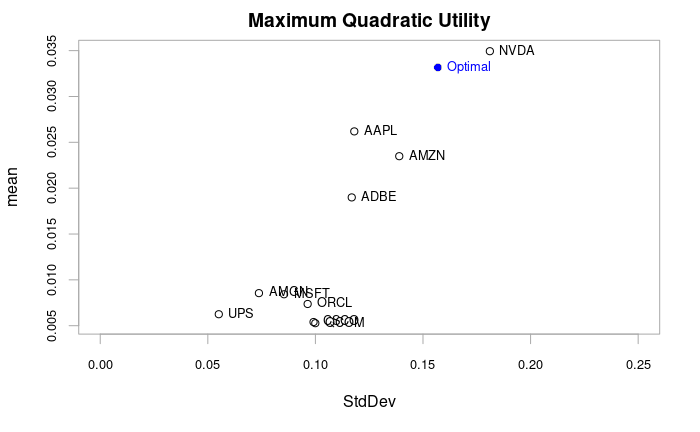

```r
chart.RiskReward(qu.opt, return.col="mean", risk.col="StdDev", chart.assets=TRUE, xlim=c(0.00,0.25), main="Maximum Quadratic Utility")
```

```r
qu.bt <- optimize.portfolio.rebalancing(xts.returns.wide, init, constraints = qu.const, objectives = qu.obj, optimize_method = "ROI", rebalance_on="months", training_period = 24, rolling_window = 48); print(qu.bt)
```

```
PortfolioAnalytics Optimization with Rebalancing

Call:
optimize.portfolio.rebalancing(R = xts.returns.wide, portfolio = init,
    constraints = qu.const, objectives = qu.obj, optimize_method = "ROI",
    rebalance_on = "months", training_period = 24, rolling_window = 48)
```

```
The weights for one or more periods do not sum up to 1: assuming a return of 0 for the residual weights
```

```
Number of rebalancing dates:  201
First rebalance date:
[1] "2001-12-31"
Last rebalance date:
[1] "2018-08-30"

Annualized Portfolio Rebalancing Return:
[1] -0.1759092

Annualized Portfolio Standard Deviation:
[1] 0.7197084
```

checking for a variety of constraints (constraints that can be computed with the `ROI`-solver) and different rebalancing periods (as well as rolling windows/training periods) to find, what might deliver you the best portfolios performance (use appropriate statistics to decide on that).

## Exercise 2: Custom moments function

Check `vignette("custom_moments_objectives")` to implement a variety of robust covariance matrix estimates (see `?MASS::cov.rob`, `?PerformanceAnalytics::ShrinkageMoments` and maybe `?PerformanceAnalytics::EWMAMoments` - the latter one only for backtesting) for the minimum variance and quadratic utility portfolios. Plot the different Efficient frontiers, optimal portfolios and weights and visualize the different covariances. Also make yourselves comfortable with cleaning outliers from your timeseries via `return.Clean()`.

Set up portfolio constraints, objectives and custom moments functions:

```r
init2 <- portfolio.spec(assets=stocks)
init2 <- add.constraint(portfolio=init2, type="full_investment")
init2 <- add.constraint(portfolio=init2, type="long_only")

sd.port <- add.objective(portfolio=init2, type="risk", name="StdDev")
maxqu.port <- add.objective(portfolio=init2, type="quadratic_utility", risk_aversion=0.25)

sigma.robust <- function(R){
  out <- list()
  set.seed(1234)
  out$sigma <- cov.rob(R, method="mcd")$cov
  return(out)
}

sigma.shrunk <- function(R){
  targets <- c(1,3,4)
  out <- list()
  out$sigmashrunk <- M2.shrink(R,targets,rowSums(R))$M2sh
  return(out)
}
```

### Optimize portfolios

Minimum variance with robust covariance estimates

```r
sd.robust.opt <- optimize.portfolio(xts.returns.wide, sd.port, optimize_method="ROI", momentFUN="sigma.robust", trace=TRUE); print(sd.robust.opt)
```

```
PortfolioAnalytics Optimization

Call:
optimize.portfolio(R = xts.returns.wide, portfolio = sd.port,
    optimize_method = "ROI", trace = TRUE, momentFUN = "sigma.robust")

Optimal Weights:
  AAPL   MSFT   AMZN   NVDA   ADBE   CSCO   AMGN   QCOM    UPS   ORCL
0.0265 0.1325 0.0000 0.0000 0.0000 0.0000 0.2100 0.0671 0.5342 0.0298

Objective Measure:
 StdDev
0.03637
```

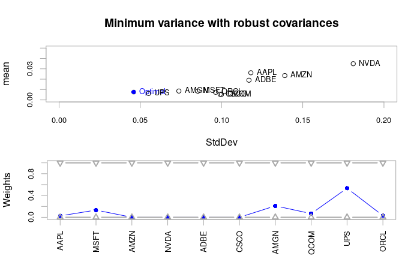

```r
plot(sd.robust.opt, risk.col = "StdDev", return.col = "mean", main="Minimum variance with robust covariances", chart.assets=TRUE, xlim=c(0, 0.2), ylim=c(0,0.05))
```

Minimum variance with shrunk covariance estimates

```r
sd.shrunk.opt <- optimize.portfolio(xts.returns.wide, sd.port, optimize_method="ROI", momentFUN="sigma.shrunk", trace=TRUE); print(sd.shrunk.opt)
```

```
PortfolioAnalytics Optimization

Call:
optimize.portfolio(R = xts.returns.wide, portfolio = sd.port,
    optimize_method = "ROI", trace = TRUE, momentFUN = "sigma.shrunk")

Optimal Weights:
  AAPL   MSFT   AMZN   NVDA   ADBE   CSCO   AMGN   QCOM    UPS   ORCL
0.0000 0.1072 0.0000 0.0000 0.0000 0.0132 0.2485 0.0439 0.5466 0.0406

Objective Measure:
 StdDev
0.04636
```

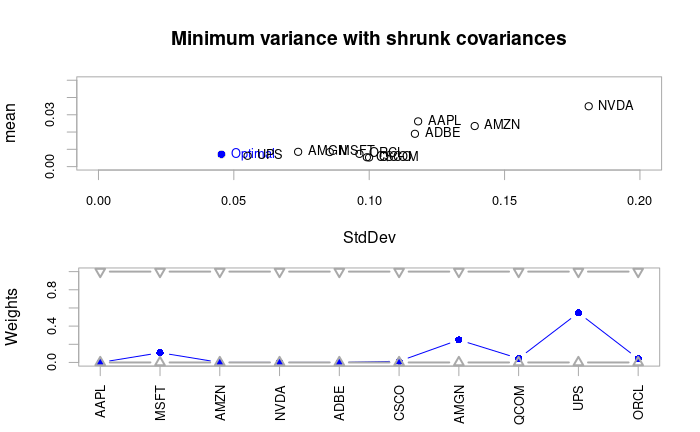

```r
plot(sd.shrunk.opt, risk.col = "StdDev", return.col = "mean", main="Minimum variance with shrunk covariances", chart.assets=TRUE, xlim=c(0, 0.2), ylim=c(0,0.05))
```

Quadratic utility with robust covariance estimates

```r
maxqu.robust.opt <- optimize.portfolio(xts.returns.wide, maxqu.port, optimize_method="ROI", momentFUN="sigma.robust", trace=TRUE); print(maxqu.robust.opt)
```

```
PortfolioAnalytics Optimization

Call:
optimize.portfolio(R = xts.returns.wide, portfolio = maxqu.port,
    optimize_method = "ROI", trace = TRUE, momentFUN = "sigma.robust")

Optimal Weights:
AAPL MSFT AMZN NVDA ADBE CSCO AMGN QCOM  UPS ORCL
   0    0    0    1    0    0    0    0    0    0

Objective Measure:
   mean
0.03494


StdDev
0.1265
```

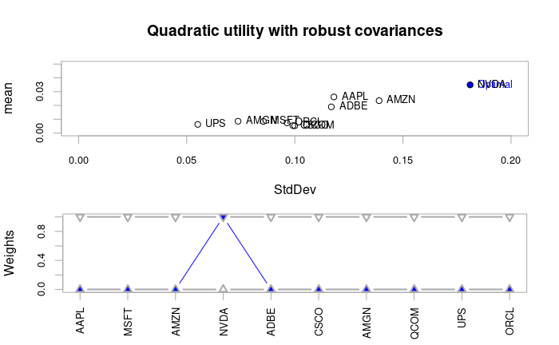

```r
plot(maxqu.robust.opt, risk.col = "StdDev", return.col = "mean", main="Quadratic utility with robust covariances", chart.assets=TRUE, xlim=c(0, 0.2), ylim=c(0,0.05))
```

Quadratic utility with shrunk covariance matrix

```r
maxqu.shrunk.opt <- optimize.portfolio(xts.returns.wide, maxqu.port, optimize_method="ROI", momentFUN="sigma.shrunk", trace=TRUE); print(maxqu.shrunk.opt)
```

```
PortfolioAnalytics Optimization

Call:
optimize.portfolio(R = xts.returns.wide, portfolio = maxqu.port,
    optimize_method = "ROI", trace = TRUE, momentFUN = "sigma.shrunk")

Optimal Weights:
AAPL MSFT AMZN NVDA ADBE CSCO AMGN QCOM  UPS ORCL
0.23 0.00 0.00 0.77 0.00 0.00 0.00 0.00 0.00 0.00

Objective Measure:
   mean
0.03293


StdDev
0.1517
```

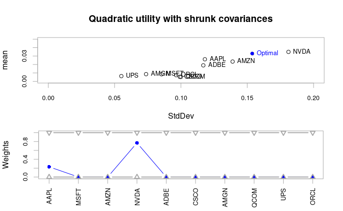

```r
plot(maxqu.shrunk.opt, risk.col = "StdDev", return.col = "mean", main="Quadratic utility with shrunk covariances", chart.assets=TRUE, xlim=c(0, 0.2), ylim=c(0,0.05))
```

### Visualize correlation matrices:

Chart of robust correlation estimates:

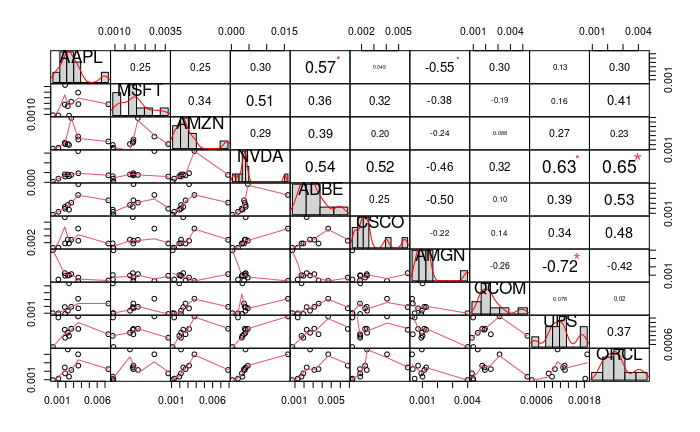

```r
#weights.sd.robust <- extractWeights(sd.robust.opt)
sigma.rob <- sigma.robust(xts.returns.wide)$sigma
#sqrt(t(weights.sd.robust)%*%sigma.rob%*%weights.sd.robust)
chart.Correlation(sigma.rob)
```

Chart of shrunk correlation estimates:

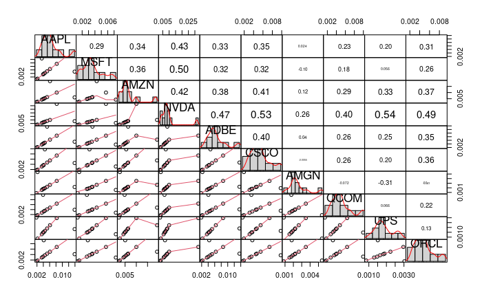

```r
#weights.sd.shrunk <- extractWeights(sd.shrunk.opt)
sigma.shrunk <- sigma.shrunk(xts.returns.wide)$sigma
#sqrt(t(weights.sd.shrunk)%*%sigma.shrunk%*%weights.sd.shrunk)
chart.Correlation(sigma.shrunk)
```

### Visualize Efficient Frontiers:

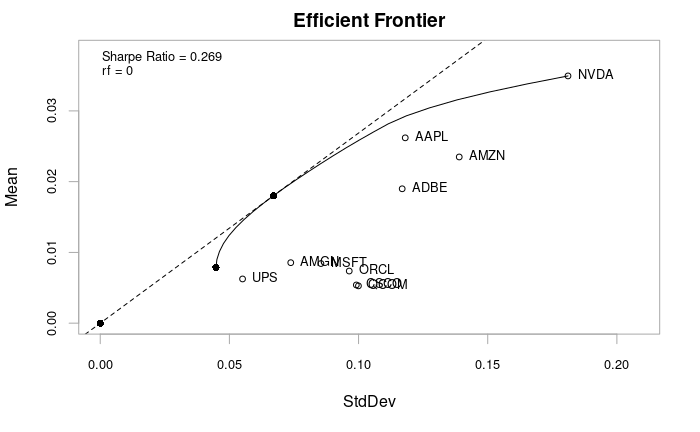

```r
sd.ef <- create.EfficientFrontier(R=xts.returns.wide, portfolio=init2, type="mean-StdDev")
chart.EfficientFrontier(sd.ef, match.col="StdDev", type="l", RAR.text="Sharpe Ratio", pch=4)
```

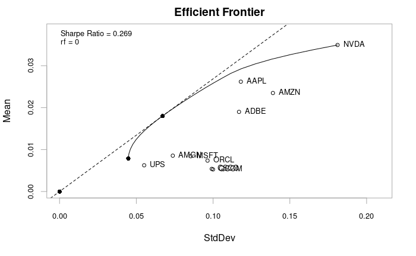

```r
maxqu.ef <- create.EfficientFrontier(R=xts.returns.wide, portfolio=init2, type="mean-var")
chart.EfficientFrontier(maxqu.ef, match.col="StdDev", type="l", RAR.text="Sharpe Ratio", pch=4)
```

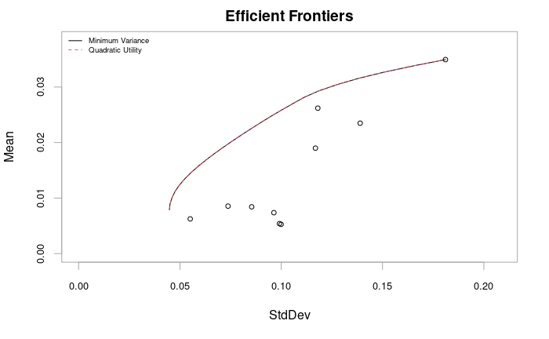

```r
port.list <- combine.portfolios(list(sd.port,maxqu.port))
chart.EfficientFrontierOverlay(xts.returns.wide,portfolio_list=port.list, type="mean-StdDev", match.col="StdDev", legend.loc="topleft", legend.labels=c("Minimum Variance","Quadratic Utility"), cex.legend=0.6, labels.assets=FALSE, pch.assets=1)
```

## Exercise 3: Regime Switching

Have a look at `demo(regime_switching)` and estimate and rebalance portfolios based on 2/3 regimes. Can you plot the regimes over time?

Create regimes:

```r
regime
```

```
           [,1]
2000-01-31    2
2000-02-29    1
2000-03-31    2
2000-04-28    1
2000-05-31    1
2000-06-30    2
2000-07-31    2
2000-08-31    1
2000-09-29    2
2000-10-31    2
2000-11-30    1
2000-12-29    2
2001-01-31    2
2001-02-28    2
2001-03-30    2
2001-04-30    1
2001-05-31    2
2001-06-29    2
2001-07-31    2
2001-08-31    1
2001-09-28    1
2001-10-31    2
2001-11-30    2
2001-12-31    1
2002-01-31    2
2002-02-28    1
2002-03-28    2
2002-04-30    2
2002-05-31    2
2002-06-28    2
2002-07-31    1
2002-08-30    1
2002-09-30    2
2002-10-31    1
2002-11-29    2
2002-12-31    2
2003-01-31    1
2003-02-28    2
2003-03-31    2
```

[output cut: 170 more lines]

```
2017-06-30    2
2017-07-31    2
2017-08-31    2
2017-09-29    2
2017-10-31    2
2017-11-30    2
2017-12-29    1
2018-01-31    2
2018-02-28    2
2018-03-29    1
2018-04-30    1
2018-05-31    2
2018-06-29    1
2018-07-31    1
2018-08-30    2
```

Construct portfolios for each regime:

Construct regime model and corresponding portfolios:

```r
regime.port <- regime.portfolios(regime,portfolios);regime.port
```

```
PortfolioAnalytics Regime Switching Specification

Regime 1 Portfolio
PortfolioAnalytics Portfolio Specification

Call:
portfolio.spec(assets = stocks)

Number of assets: 10
Asset Names
 [1] "AAPL" "MSFT" "AMZN" "NVDA" "ADBE" "CSCO" "AMGN" "QCOM" "UPS"  "ORCL"

Constraints
Enabled constraint types
        - weight_sum
        - box (long only)

Objectives:
Enabled objective names
        - ES
        - ES

Regime 2 Portfolio
PortfolioAnalytics Portfolio Specification

Call:
portfolio.spec(assets = stocks)

Number of assets: 10
Asset Names
 [1] "AAPL" "MSFT" "AMZN" "NVDA" "ADBE" "CSCO" "AMGN" "QCOM" "UPS"  "ORCL"

Constraints
Enabled constraint types
        - weight_sum
        - box (long only)

Objectives:
Enabled objective names
        - StdDev
        - StdDev
```

Optimize portfolios:

```r
opt1 <- optimize.portfolio(xts.returns.wide,regime.port,optimize_method = "random", search_size = 2000, trace=TRUE); print(opt1)
```

```
PortfolioAnalytics Optimization

Call:
optimize.portfolio(R = xts.returns.wide, portfolio = regime.port,
    optimize_method = "random", search_size = 2000, trace = TRUE)

Optimal Weights:
 AAPL  MSFT  AMZN  NVDA  ADBE  CSCO  AMGN  QCOM   UPS  ORCL
0.032 0.108 0.036 0.026 0.000 0.022 0.196 0.000 0.380 0.232

Objective Measures:
 StdDev
0.05242

contribution :
    AAPL     MSFT     AMZN     NVDA     ADBE     CSCO     AMGN     QCOM      UPS     ORCL
0.001930 0.005905 0.002883 0.002426 0.000000 0.001418 0.007096 0.000000 0.013687 0.017077

pct_contrib_StdDev :
   AAPL    MSFT    AMZN    NVDA    ADBE    CSCO    AMGN    QCOM     UPS    ORCL
0.03681 0.11264 0.05499 0.04627 0.00000 0.02706 0.13536 0.00000 0.26110 0.32576
```

```r
opt1$regime
```

```
[1] 2
```

```r
opt2 <- optimize.portfolio(xts.returns.wide[1:nrow(xts.returns.wide)-1],regime.port,optimize_method = "DEoptim", search_size = 2000, trace=TRUE); print(opt2)
```

[output not shown]

[output cut: 47 more lines]

```r
opt2$regime
```

```
[1] 1
```

```r
opt.rebal <- optimize.portfolio.rebalancing(xts.returns.wide,regime.port, optimize_method = "random", rebalance_on = "months", training_period = 36, search_size = 2000, trace=TRUE); print(opt.rebal)
```

[output not shown]

## Exercise 4: Single Index-Model

Now we are going to estimate the Portfolio Input Parameters with the Single-Index Model. Use your ten assets and additionally choose the S&P500 as index (same returns etc).

```r
sp500.xts <- SP500 %>% pivot_wider(.,names_from=symbol,values_from=monthly.returns) %>% tk_xts(silent = TRUE); round(sp500.xts[1:20,],digits = 5)
```

```
              ^GSPC
2000-01-31 -0.04175
2000-02-29 -0.02011
2000-03-31  0.09672
2000-04-28 -0.03080
2000-05-31 -0.02192
2000-06-30  0.02393
2000-07-31 -0.01634
2000-08-31  0.06070
2000-09-29 -0.05348
2000-10-31 -0.00495
2000-11-30 -0.08007
2000-12-29  0.00405
2001-01-31  0.03464
2001-02-28 -0.09229
2001-03-30 -0.06420
2001-04-30  0.07681
2001-05-31  0.00509
2001-06-29 -0.02504
2001-07-31 -0.01074
2001-08-31 -0.06411
```

1. Regress all stocks on the index. Show alpha, beta and residual variance. Calculate systematic and firm-specific risk. Are there any significant alphas? (You should double check with the appropriate `PerformanceAnalytics` Functions) Alpha:

```r
alpha <- CAPM.alpha(xts.returns.wide,sp500.xts,0);print(alpha)
```

```
                  AAPL        MSFT       AMZN       NVDA       ADBE          CSCO        AMGN        QCOM         UPS        ORCL
Alpha: ^GSPC 0.0193637 0.004396895 0.01560832 0.02334339 0.01279058 -0.0005236088 0.006088323 0.001878822 0.003088299 0.002704858
```

Beta:

```r
beta <- CAPM.beta(xts.returns.wide,sp500.xts,0);print(beta)
```

```
                AAPL     MSFT     AMZN     NVDA     ADBE     CSCO      AMGN     QCOM       UPS     ORCL
Beta: ^GSPC 1.420551 1.203609 1.662814 2.172973 1.456908 1.526797 0.6325145 1.185988 0.7955739 1.241405
```

Residual Standard Deviation:

```r
reg <- summary(lm(xts.returns.wide~sp500.xts))
plyr::ldply(reg, function(x)x$sigma)
```

| .id | V1 |
| --- | --- |
| Response AAPL | 0.10100509 |
| Response MSFT | 0.06753133 |
| Response AMZN | 0.11830943 |
| Response NVDA | 0.15582978 |
| Response ADBE | 0.09732934 |
| Response CSCO | 0.07439714 |
| Response AMGN | 0.06857205 |
| Response QCOM | 0.09322481 |
| Response UPS | 0.04708329 |
| Response ORCL | 0.07975338 |

Systematic Risk:

```r
systematic.risk <- SystematicRisk(xts.returns.wide,sp500.xts,0);print(systematic.risk)
```

```
                                       AAPL      MSFT     AMZN      NVDA      ADBE      CSCO       AMGN      QCOM       UPS      ORCL
Systematic Risk to ^GSPC (Rf = 0) 0.2069255 0.1753246 0.242215 0.3165276 0.2122214 0.2224019 0.09213566 0.1727577 0.1158878 0.1808301
```

Firm-specific Risk:

```r
spec.risk <- SpecificRisk(xts.returns.wide,sp500.xts,0);print(spec.risk)
```

```
                      AAPL     MSFT      AMZN     NVDA     ADBE      CSCO      AMGN      QCOM       UPS      ORCL
Specific Risk =  0.3484062 0.232942 0.4080956 0.537518 0.335727 0.2566249 0.2365319 0.3215689 0.1624087 0.2751007
```

Significant Alphas:

| .id | Estimate | Std. Error | t value | Pr(>\|t\|) |
| --- | --- | --- | --- | --- |
| Response AAPL | 0.0193636985 | 0.006602613 | 2.9327325 | 0.003693551 |
| Response MSFT | 0.0043968946 | 0.004414463 | 0.9960202 | 0.320269161 |
| Response AMZN | 0.0156083235 | 0.007733783 | 2.0182005 | 0.044711646 |
| Response NVDA | 0.0233433863 | 0.010186455 | 2.2916105 | 0.022817396 |
| Response ADBE | 0.0127905839 | 0.006362332 | 2.0103608 | 0.045540648 |
| Response CSCO | -0.0005236088 | 0.004863275 | -0.1076659 | 0.914352976 |
| Response AMGN | 0.0060883233 | 0.004482494 | 1.3582446 | 0.175694158 |
| Response QCOM | 0.0018788222 | 0.006094023 | 0.3083057 | 0.758123988 |
| Response UPS | 0.0030882988 | 0.003077793 | 1.0034135 | 0.316697879 |
| Response ORCL | 0.0027048578 | 0.005213408 | 0.5188272 | 0.604371541 |

The Alphas of AAPL, AMZN, NVDA and ADBE are significant at the 95% condifence level.

2. Extract the betas and calculate systematic and unsystematic risk, derive the whole covariance matrix. To do this you can use *CH15_Factor_Modfels_for_Asset_Returns.pdf (15.3.1)* and the code implemented in the function sharpeFactorEstimator that you find [here](http://financewithr.blogspot.com/2013/06/portfolio-optimization-using-single.html) (please do not just copy everything, but try to understand what you are doing, e.g. check why and if G.hat has the same values as found by the multivariate regression). Systematic Risk

```r
systematic.risk <- SystematicRisk(xts.returns.wide,sp500.xts,0);print(systematic.risk)
```

```
                                       AAPL      MSFT     AMZN      NVDA      ADBE      CSCO       AMGN      QCOM       UPS      ORCL
Systematic Risk to ^GSPC (Rf = 0) 0.2069255 0.1753246 0.242215 0.3165276 0.2122214 0.2224019 0.09213566 0.1727577 0.1158878 0.1808301
```

Unsystematic Risk:

```r
spec.risk <- SpecificRisk(xts.returns.wide,sp500.xts,0);print(spec.risk)
```

```
                      AAPL     MSFT      AMZN     NVDA     ADBE      CSCO      AMGN      QCOM       UPS      ORCL
Specific Risk =  0.3484062 0.232942 0.4080956 0.537518 0.335727 0.2566249 0.2365319 0.3215689 0.1624087 0.2751007
```

```r
factors <- berndt[, 10]
```

[output not shown]

3. Now use the *custom-moments* functions from Exercise 2 to implement the single-factor model into the portfolio optimization framework and plot the efficient frontier using the parameters estimated by the single factor model next to the EF of the full-covariance model. Calculate MVP, TP etc. and work out the differences in weights, portfolio return and portfolio risk.